# Making Water Budgets with nCLIMDIV Data

# 1 Intro Data Pulls Divisional Climate Data

# 2 Libraries

] The following libraries are needed for this exercise.

Tidyverse Packages

- [tidyverse](https://www.tidyverse.org) : Set of commonly-used Data Science packages for R that it can install and load all at once. In the long-run you probably also want to install the tidyverse package suite anyway. For this exercise this will include…
  - [ggplot2](https://ggplot2.tidyverse.org) : Create Elegant Data Visualizations Using the Grammar of Graphics
  - [tibble](https://tibble.tidyverse.org) : Simple Data Frames
  - [tidyr](https://tidyr.tidyverse.org) : Tools for shepherding data in data frames.
  - [readr](https://readr.tidyverse.org) : Read Rectangular Text Data
  - [purr](https://purrr.tidyverse.org) : Functional Programming Tools
  - [dplyr](https://dplyr.tidyverse.org) : A grammar of data manipulation
  - [stringr](https://stringr.tidyverse.org) : Simple, Consistent Wrappers for Common String Operations
  - [forcats](https://forcats.tidyverse.org) : Tools for Working with Categorical Variables (Factors)
- [lubridate](https://lubridate.tidyverse.org) : Time and Date Management

Other Packates

- [ClimClass](https://www.rdocumentation.org/packages/ClimClass/versions/2.1.0) Climate Classification According to Several Indices (includes the Thornthwaite Mather Budgets)

```r
# Libraries

  # Tidyverse resour(ces

  library(package = "tidyverse") # Multiple Tidyverse Resources
  library(package = "lubridate") # Date-Time Control

  # Other Packages

  library(package = "ClimClass") #
```

# 3 Pulling the NCEI Cliamte Division Data

We keep a copy of the NCDI Climate Division Data in an R-Readable format on our SDMINES servers. It is read with a simple [load()](https://www.rdocumentation.org/packages/base/versions/3.6.0/topics/load) command with a [url()](https://www.rdocumentation.org/packages/base/versions/3.6.0/topics/connections) function to reach into the internet and pull a copy of that dataset.

```r
# Pull nCLIMDIV Data from SD Mines Data Server

load(file = url(description = "http://kyrill.ias.sdsmt.edu:8080/thredds/fileServer/CLASS_Examples/nCLIMDIV.Rdata"))
```

# 4 Selecting the Cliamte Zone.

State climate division are identified by two 2-number identifiers. The first identifier code is the state code (called a WIMS code). This is shown here for the Contigious US (aka “CONUS”) which doesn’t include Alaska, Hawaii or overseas territory:

**Map of State WIMS codes** https://gacc.nifc.gov/sacc/predictive/weather/WIMS%20ID%20MAPS/WIMS_STATE_NUMBERS.jpg

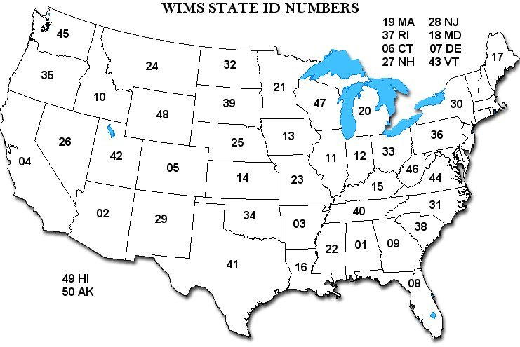

The second code is for the cliamte zone for each state. Below is a map of the US for the climate regions within each CONUS state.

**Map of NCEI Climate Zones** https://www.ncdc.noaa.gov/monitoring-references/maps/images/us-climate-divisions.gif

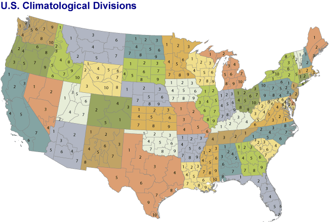

The zones are also shown here in tablular form

```r
# Simple Table of Climate Zones Grouped by State

print(unique(nCLIMDIV %>% select(Full_Zone_Code,
                                 State_Name,
                                 Zone_Name,
                                 Center_Lon,
                                 Center_Lat)))
```

| Full_Zone_Code | State_Name | Zone_Name | Center_Lon | Center_Lat |
| --- | --- | --- | --- | --- |
| 0101 | Alabama | North Valley | -87 | 35 |
| 0102 | Alabama | Appalachian Mountain | -86 | 34 |
| 0103 | Alabama | Upper Plains | -87 | 33 |
| 0104 | Alabama | Eastern Valley | -86 | 34 |
| 0105 | Alabama | Piedmont Plateau | -86 | 33 |
| 0106 | Alabama | Prairie | -87 | 32 |
| 0107 | Alabama | Coastal Plain | -87 | 32 |
| 0108 | Alabama | Gulf | -88 | 31 |
| 0201 | Arizona | Northwest | -114 | 36 |
| 0202 | Arizona | Northeast | -111 | 36 |

[output cut: 334 more lines]

```r
NA
```

# 5 USER MODIFICATION AREA

This is the part of the code that you play with. Here you will be prompted for

Zones and Times

- a single climate zone 2x2-digit selected from above
  - Example: “3904” for the Black Hills, South Dakota
- period for which you want plots
  - the budget model will calculate budgets for the whole period of data. It will only plot for the period for which you ask.
- spinup period
  - the “model” needs some time to run to lose “memory” of its initial conditions so that it is driven by the current and recent climate forcing
  - you don’t really to worry about this much - I just use about 10 years for this kind of budget model.

Model Specific Data

- initial snow water storage (the influence of this, we call this “memory,” will decrease as the budget model runs.)
  - Example: 0 mm for Southern Florida; 20 mm for South Dakota
- total soil reservoir storage (total “depth” of moisture available for the atmosphere to access)
  - 100 mm or 150 mm tends to work well here. You probably won’t want to chage this much either

```r
# User Modification Data

  target_climate_zone = "3904" # enter as a 4-digit string in quotation marks

  start_plot_year = 2010
  end_plot_year   = 2018

  spinup_period   = 10 # calendar years for spinup period


  soil_zone_capacity = 100 # soil reservoir storage capacity in mm
  initial_snow_cover =   0 # snow reservoir storage capacity in mm
```

# 6 Selecting Data from the original nCLIMDIV data set

```r
single_zone = nCLIMDIV %>% filter(Full_Zone_Code == target_climate_zone)

print(single_zone)
```

| Full_Zone_Code | Date | CDDC | HDDC | PCPN | PDSI | PHDI | PMDI | SP01 | SP02 | SP03 | SP06 | SP09 | SP12 | SP24 | TMAX | TMIN | TMPC | ZNDX | State_Name | Zone_Name | Center_Lon | Center_Lat |
| --- | --- | --- | --- | --- | --- | --- | --- | --- | --- | --- | --- | --- | --- | --- | --- | --- | --- | --- | --- | --- | --- | --- |
| 3904 | 1895-01-15 | 0 | 1535 | 1.23 | 1.17 | 1.17 | 1.17 | 1.44 | NA | NA | NA | NA | NA | NA | 27 | 4.3 | 15.5 | 3.51 | South Dakota | Black Hills | -104 | 44 |
| 3904 | 1895-02-15 | 0 | 1400 | 1.85 | 2.72 | 2.72 | 2.72 | 2.41 | 2.53 | NA | NA | NA | NA | NA | 26 | 3.6 | 15.0 | 5.01 | South Dakota | Black Hills | -104 | 44 |
| 3904 | 1895-03-15 | 0 | 1156 | 2.35 | 4.22 | 4.22 | 4.22 | 1.99 | 2.70 | 2.66 | NA | NA | NA | NA | 39 | 16.1 | 27.7 | 5.33 | South Dakota | Black Hills | -104 | 44 |
| 3904 | 1895-04-15 | 0 | 576 | 2.67 | 4.25 | 4.25 | 4.25 | 0.60 | 1.43 | 2.14 | NA | NA | NA | NA | 59 | 33.0 | 45.8 | 1.39 | South Dakota | Black Hills | -104 | 44 |
| 3904 | 1895-05-15 | 0 | 490 | 4.25 | 4.66 | 4.66 | 4.66 | 0.61 | 0.72 | 1.20 | NA | NA | NA | NA | 61 | 37.1 | 49.2 | 2.56 | South Dakota | Black Hills | -104 | 44 |
| 3904 | 1895-06-15 | 16 | 295 | 5.15 | 5.31 | 5.31 | 5.31 | 1.09 | 1.00 | 1.09 | 2.00 | NA | NA | NA | 67 | 44.2 | 55.7 | 3.37 | South Dakota | Black Hills | -104 | 44 |
| 3904 | 1895-07-15 | 89 | 101 | 0.89 | 4.36 | 4.36 | 3.87 | -2.51 | 0.11 | 0.37 | 1.12 | NA | NA | NA | 78 | 50.8 | 64.6 | -1.18 | South Dakota | Black Hills | -104 | 44 |
| 3904 | 1895-08-15 | 74 | 89 | 1.12 | 3.68 | 3.68 | 2.87 | -0.93 | -2.34 | -0.25 | 0.54 | NA | NA | NA | 79 | 50.0 | 64.5 | -0.71 | South Dakota | Black Hills | -104 | 44 |
| 3904 | 1895-09-15 | 14 | 308 | 0.67 | 2.92 | 2.92 | 1.66 | -0.81 | -1.34 | -2.51 | 0.00 | 0.75 | NA | NA | 72 | 39.0 | 55.2 | -1.14 | South Dakota | Black Hills | -104 | 44 |
| 3904 | 1895-10-15 | 0 | 698 | 0.25 | 2.16 | 2.16 | 0.41 | -1.79 | -1.64 | -2.08 | -0.36 | 0.38 | NA | NA | 57 | 28.0 | 42.5 | -1.38 | South Dakota | Black Hills | -104 | 44 |

[output cut: 990 more lines]

```r
NA
```

# 7 Creating the Thornthwaite Budget

There is a lot happening here and the process is not very pretty and hard to follow. It DOES, however work and this probably can be glossed over with some “some kind of miracle happens here” jingly-keys. I will eventually make this section look prettier but right now you don’t need to worry about this.

The function to generate the thorntwaite budget is called [thonthwaite()](https://www.rdocumentation.org/packages/ClimClass/versions/2.1.0/topics/thornthwaite)

The procedure is summarized as follows

- place the data into a simple data frame with specific column headers (one line is one calendar-month in a time series)
  - year (calendar year)
  - month (calendar month)
  - P (monthly rainfall total in mm)
  - Tn (averaged minimum daily temperature for the month in °C)
  - Tx (averaged maximum daily temperature for the month in °C)
  - Tn (averaged mean daily temperature for the month in °C)
- execute the [thonthwaite()](https://www.rdocumentation.org/packages/ClimClass/versions/2.1.0/topics/thornthwaite) function
- clean up the serious-ugly™️ mess that is the thonrthwaite output.
  - convert the output from the model into a data frame. That explicit output (all in mm) is
    - potential evaporation
    - precipitation
    - precipitation - potential evaporation
    - soil water storage
    - deficit between potential evaporaton and true evaporation
    - surplus which includes the acutal surplus and the recharge of the soil.
  - create additional fields to complete the budget
    - true evaporation
    - separate surplus and recharge
    - add the snow water storage

```r
{

  # first create a smaller data frame with year, month, precip (mm), and Max, Min or Mean Temps (all in °C)

  {

    thorntwaite_inputs = data_frame(year   = year(single_zone$Date),
                                    month  = month(single_zone$Date),
                                    P      = single_zone$PCPN *  25.4,
                                    Tn     = (single_zone$TMIN - 32) * 5./9,
                                    Tx     = (single_zone$TMAX - 32) * 5./9) #,
                                 # Tm     = (single_zone$TMPC - 32) * 5./9)

  }


# run it through the function thornthwaite.  It returns a nested data frame called an "S3"

  {

    thorntwaite_budget_raw = thornthwaite(series          = thorntwaite_inputs,
                                          latitude        = single_zone$Center_Lat[1],
                                          clim_norm       = NULL,
                                          first.yr        = min(thorntwaite_inputs$year),
                                          last.yr         = 2018,
                                          quant           = c(0, 0.1, 0.25, 0.5, 0.75, 0.9, 1),
                                          snow.init       = initial_snow_cover,
                                          Tsnow           = -1,
                                          TAW             = soil_zone_capacity,
                                          fr.sn.acc       = 0.95,
                                          snow_melt_coeff = 1)

  }

  # collect the output into a single data frame. (this probably could be made more prettier)
  {

    # Precipitation
      water_budget = t( as_tibble(thorntwaite_budget_raw$W_balance$Precipitation) )
      colnames(water_budget) = str_c(1:12)
      water_budget = water_budget %>%
        as.data.frame %>%
        rownames_to_column(.,
                           var = 'year')
      water_budget$Variable = "Precipitation"

    #Et0
      raw_wb2 = t( as_tibble(thorntwaite_budget_raw$W_balance$Et0) )
      colnames(raw_wb2) = str_c(1:12)
      raw_wb2 = raw_wb2 %>%
        as.data.frame %>%
        rownames_to_column(.,
                           var = 'year')
      raw_wb2$Variable = "Potential_Evap"

      water_budget = rbind(water_budget,raw_wb2)
      remove(raw_wb2)

    #Storage
      raw_wb2           = t( as_tibble(thorntwaite_budget_raw$W_balance$Storage) )
      colnames(raw_wb2) = str_c(1:12)
      raw_wb2 = raw_wb2 %>%
        as.data.frame %>%
        rownames_to_column(.,
                           var = 'year')
      raw_wb2$Variable = "Storage"

      water_budget = rbind(water_budget,raw_wb2)
      remove(raw_wb2)

    #'Prec. - PotEvap.'
      raw_wb2 = t( as_tibble(thorntwaite_budget_raw$W_balance$'Prec. - Evap.') )
      colnames(raw_wb2) = str_c(1:12)
      raw_wb2 = raw_wb2 %>%
        as.data.frame %>%
        rownames_to_column(.,
                           var = 'year')
      raw_wb2$Variable = "Prec_m_PE"

      water_budget = rbind(water_budget,raw_wb2)
      remove(raw_wb2)

    #Deficit
      raw_wb2 = t( as_tibble(thorntwaite_budget_raw$W_balance$Deficit) )
      colnames(raw_wb2) = str_c(1:12)
      raw_wb2 = raw_wb2 %>%
        as.data.frame %>%
        rownames_to_column(.,
                           var = 'year')
      raw_wb2$Variable = "Deficit"

      water_budget = rbind(water_budget,raw_wb2)
      remove(raw_wb2)

    #Surplus
      raw_wb2 = t( as_tibble(thorntwaite_budget_raw$W_balance$Surplus) )
      colnames(raw_wb2) = str_c(1:12)
      raw_wb2 = raw_wb2 %>%
        as.data.frame %>%
        rownames_to_column(.,
                           var = 'year')
      raw_wb2$Variable = "Surplus"

      water_budget = rbind(water_budget, raw_wb2)
      remove(raw_wb2)

    water_budget = gather(data  = water_budget,
                          key   = month,
                          value = "value",
                          str_c(1:12))

    water_budget$Date = as.Date(str_c(water_budget$year,
                                      "-",
                                      water_budget$month,
                                      "-15",
                                      sep = ""))

    water_budget = spread(data = water_budget,
                          key  = "Variable",
                          value = "value")

    water_budget = water_budget %>% arrange(Date)

  }

  # finish the budget by critical parameters
  {

    # calculate evapotransporation
    water_budget = water_budget %>%
                      mutate(Evaporation = Potential_Evap - Deficit)

    # calculate precipitation - true evaporation
    water_budget = water_budget %>%
                      mutate(Prec_m_Evap = Precipitation - Evaporation)

    # calculate recharge by calculating the increase in soil storage from rainfall
    water_budget = water_budget %>%
                      mutate(Recharge = c(NA, diff(x = Storage,
                                                   lag = 1))) %>%
                      mutate(Recharge = ifelse(test = Recharge>0,
                                               yes  = Recharge,
                                               no   = 0))

    # separate recharge from surplus in teh water budget
    water_budget = water_budget %>%
                      mutate(Surplus = Surplus - Recharge)  %>%
                      mutate(Surplus = ifelse(test = Surplus>0,
                                              yes = Surplus,
                                              no  = 0))

    # calculate recharge by calculating the increase in soil storage from rainfall
    water_budget = water_budget %>%
                      mutate(Snowpack = Prec_m_Evap - Recharge - Surplus)  %>%
                      mutate(Snowpack = ifelse(test = Snowpack>0,
                                                yes = Snowpack,
                                                no  = 0))

  }

  # clean up the mess
  remove(thorntwaite_budget_raw)
  remove(thorntwaite_inputs)

}

print(water_budget)
```

| year | month | Date | Deficit | Potential_Evap | Prec_m_PE | Precipitation | Storage | Surplus | Evaporation | Prec_m_Evap | Recharge | Snowpack |
| --- | --- | --- | --- | --- | --- | --- | --- | --- | --- | --- | --- | --- |
| 1895 | 1 | 1895-01-15 | 0.0 | 0.0 | 3.1 | 31.2 | 100.0 | NA | 0.0 | 31.2 | NA | NA |
| 1895 | 2 | 1895-02-15 | 0.0 | 0.0 | 4.7 | 47.0 | 100.0 | 4.7 | 0.0 | 47.0 | 0.0 | 4.2e+01 |
| 1895 | 3 | 1895-03-15 | 0.0 | 0.0 | 6.0 | 59.7 | 100.0 | 6.0 | 0.0 | 59.7 | 0.0 | 5.4e+01 |
| 1895 | 4 | 1895-04-15 | 0.0 | 46.1 | 147.4 | 67.8 | 100.0 | 147.4 | 46.1 | 21.7 | 0.0 | 0.0e+00 |
| 1895 | 5 | 1895-05-15 | 0.0 | 62.3 | 45.7 | 107.9 | 100.0 | 45.7 | 62.3 | 45.6 | 0.0 | 0.0e+00 |
| 1895 | 6 | 1895-06-15 | 0.0 | 89.1 | 41.8 | 130.8 | 100.0 | 41.8 | 89.1 | 41.7 | 0.0 | 0.0e+00 |
| 1895 | 7 | 1895-07-15 | 33.7 | 118.6 | -96.0 | 22.6 | 37.8 | 0.0 | 84.9 | -62.3 | 0.0 | 0.0e+00 |
| 1895 | 8 | 1895-08-15 | 59.9 | 109.5 | -81.1 | 28.4 | 16.6 | 0.0 | 49.6 | -21.2 | 0.0 | 0.0e+00 |
| 1895 | 9 | 1895-09-15 | 47.2 | 71.2 | -54.2 | 17.0 | 9.6 | 0.0 | 24.0 | -7.0 | 0.0 | 0.0e+00 |
| 1895 | 10 | 1895-10-15 | 21.1 | 29.4 | -23.1 | 6.3 | 7.6 | 0.0 | 8.3 | -2.0 | 0.0 | 0.0e+00 |

[output cut: 990 more lines]

```r
NA
```

#8 And finally we can plot the data

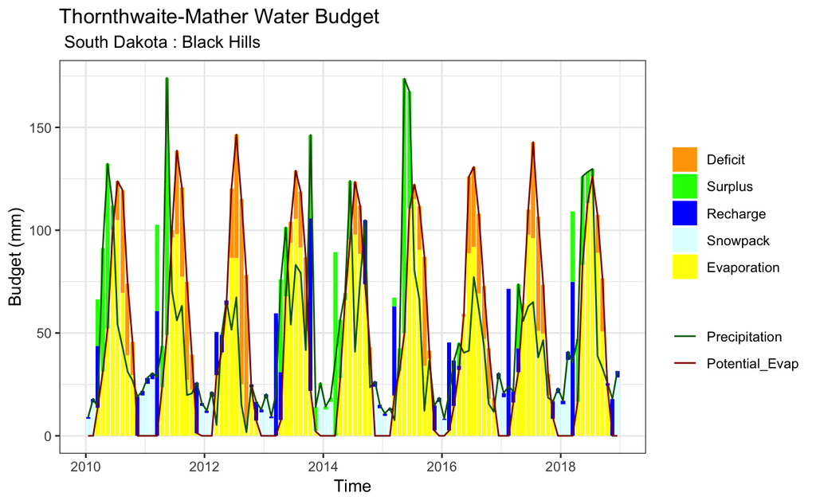

```r
# trying to make a plot.

# making two datasets, one for lines, the other for bars

subset = water_budget %>% filter((year(Date) >= start_plot_year) &
                                 (year(Date) <= end_plot_year)   )

  subset_lines = subset %>% select(Date,
                                    Precipitation,
                                    Potential_Evap)

  subset_lines = gather(data  = subset_lines,
                         value = "Value",
                         key   = "Variable",
                         Precipitation,
                         Potential_Evap)

  subset_lines$Variable = as_factor(subset_lines$Variable)

subset_bars = subset %>% select(Date,
                                  Evaporation,
                                  Surplus,
                                  Recharge,
                                  Snowpack,
                                  Deficit)

subset_bars = gather(data  = subset_bars,
                                       value = "Value",
                                       key   = "Variable",
                                       Deficit,
                                       Surplus,
                                       Recharge,
                                       Snowpack,
                                       Evaporation)

subset_bars$Variable = as_factor(subset_bars$Variable)



ggplot(data = subset_lines) +

  theme_bw() +

  aes(x     = Date,
      y     = Value) +


  ggtitle(label    = "Thornthwaite-Mather Water Budget",
          subtitle = str_c(unique(single_zone$State_Name),
                         unique(single_zone$Zone_Name),
                         sep = " : ")) +

  xlab(label = "Time") +

  ylab(label = "Budget (mm)") +

  scale_fill_manual(values = c( "Precipitation"  = "darkgreen",
                                "Potential_Evap" = "darkred",
                                "Deficit"     = "orange",
                                "Surplus"     = "green",
                                "Recharge"    = "blue",
                                "Snowpack"    = "lightcyan",
                                "Evaporation" = "yellow"),
                     name = NULL)+



  geom_bar(data    = subset_bars,
           mapping = aes(x     = Date,
                          y    = Value,
                          fill = Variable),
           stat = 'identity',
           position = "stack") +

  scale_color_manual(values = c( "Precipitation"  = "darkgreen",
                                "Potential_Evap" = "darkred",
                                "Deficit"     = "orange",
                                "Surplus"     = "green",
                                "Recharge"    = "blue",
                                "Snowpack"    = "lightcyan",
                                "Evaporation" = "yellow"),
                     name = NULL) +



  geom_line(data    = subset_lines,
            mapping = aes(x     = Date,
                          y     = Value,
                          color = Variable,
                          fill  = NULL))
```

```r
NA
NA
NA
```